# practical_exercise_2, Methods 3, 2021, autumn semester

Mie Buchhave Søgaard

29.09.2021

# Assignment 1: Using mixed effects modelling to model hierarchical data

*In this assignment we will be investigating the *politeness* dataset of Winter and Grawunder (2012) and apply basic methods of multilevel modelling.*

### Dataset

*The dataset has been shared on GitHub, so make sure that the csv-file is on your current path. Otherwise you can supply the full path.*

```r
politeness <- read.csv('politeness.csv') ## read in data
```

# Exercises and objectives

The objectives of the exercises of this assignment are:  
1) Learning to recognize hierarchical structures within datasets and describing them  
2) Creating simple multilevel models and assessing their fitness  
3) Write up a report about the findings of the study

## Exercise 1 - describing the dataset and making some initial plots

### 1) Describe the dataset, such that someone who happened upon this dataset could understand the variables and what they contain

*i. Also consider whether any of the variables in *politeness* should be encoded as factors or have the factor encoding removed.*

```r
politeness <- politeness %>%
    filter(!is.na(f0mn)) # Removing NA's

head(politeness)
```

|  | subject | gender | scenario | attitude | total_duration | f0mn | hiss_count |
| --- | --- | --- | --- | --- | --- | --- | --- |
| 1 | F1 | F | 1 | pol | 18.392 | 214.6 | 2 |
| 2 | F1 | F | 1 | inf | 13.551 | 210.9 | 0 |
| 3 | F1 | F | 2 | pol | 5.217 | 284.7 | 0 |
| 4 | F1 | F | 2 | inf | 4.247 | 265.6 | 0 |
| 5 | F1 | F | 3 | pol | 6.791 | 210.6 | 0 |
| 6 | F1 | F | 3 | inf | 4.126 | 285.6 | 0 |

**The dataset consists of seven variables:**  
**subject** : Contains the subject ID.  
**gender** : *F* indicating that the subject is female and *M* indicating that the subject is male.  
**scenario** : each scenario being a different sentence that the subject had to say.  
**attitude** : Indicating whether the sentence was said in a “**pol**ite” or “**inf**ormal” context.  
**total_duration** : The duration of utterances (seconds).  
**f0mn** : The mean frequency of participants’ voice pitch (higher values is higher pitch).  
**hiss_count** : A count of noisy breath intakes.

One might strongly consider to encode *scenario* as a factor. The *scenario* is currently encoded as integer, but because of the fact that the different scenarios are independent categories, it should be encoded as a factor. If one keeps *scenario* as integer, the model will treat the variable as a continuum, and that is not preferable here. In relation to the character variables, factors and character vectors are not treated differently when modelling the data. However, when doing model comparisons (ANOVA’s), character variables are converted to factor variables, and it could therefore be considered to encode them as factors already from the beginning.

### 2) Create a new data frame that just contains the subject *F1* and run two linear models; one that expresses *f0mn* as dependent on *scenario* as an integer; and one that expresses *f0mn* as dependent on *scenario* encoded as a factor

**i. Include the model matrices, $X$ from the General Linear Model, for these two models in your report and describe the different interpretations of *scenario* that these entail.**

```r
# a dataframe for F1 only
f1 <- politeness %>%
  filter(subject == "F1") %>%
  mutate(scenario_factor = scenario) # Making a variable for the factorized scenario, so both the numeric and factor version are in the dataframe simultaneously.

f1$scenario_factor <- as.factor(f1$scenario_factor)
f1$scenario <- as.integer(f1$scenario)

lm_i <- lm(f0mn ~ scenario, f1)

lm_f <- lm(f0mn ~ scenario_factor, f1)
```

```r
X_integer <-  model.matrix(lm_i)

X_factor <-  model.matrix(lm_f)

X_integer
```

```
##    (Intercept) scenario
## 1            1        1
## 2            1        1
## 3            1        2
## 4            1        2
## 5            1        3
## 6            1        3
## 7            1        4
## 8            1        4
## 9            1        5
## 10           1        5
## 11           1        6
## 12           1        6
## 13           1        7
## 14           1        7
## attr(,"assign")
## [1] 0 1
```

```r
X_factor
```

```
##    (Intercept) scenario_factor2 scenario_factor3 scenario_factor4
## 1            1                0                0                0
## 2            1                0                0                0
## 3            1                1                0                0
## 4            1                1                0                0
## 5            1                0                1                0
## 6            1                0                1                0
## 7            1                0                0                1
## 8            1                0                0                1
## 9            1                0                0                0
## 10           1                0                0                0
## 11           1                0                0                0
## 12           1                0                0                0
## 13           1                0                0                0
## 14           1                0                0                0
```

[output cut: 20 more lines]

```r
politeness$scenario <- as.factor(politeness$scenario)
```

As we see, we get two different outputs for the matrices when *scenario* is encoded as integer and factor, resprectively. When *scenario* is modelled as integer, the model treats it as a continuum, i.e. that, for example, scenario 4 is four times scenario 1, which is not the case. When coded as a factor, *scenario* is treated categorically - thus, the different scenarios independent from each other. Thus coded as integer, there is a high chance of losing relevant information.

**ii. Which coding of *scenario*, as a factor or not, is more fitting?** The factorized version is more fitting. The numbers in scenario should not be treated as continuum (no floats), but should instead be treated as independent categories, which becomes the case when *scenario* is factorized.

### 3) Make a plot that includes a subplot for each subject that has *scenario* on the x-axis and *f0mn* on the y-axis and where points are colour coded according to *attitude*.

**i. Describe the differences between subjects**

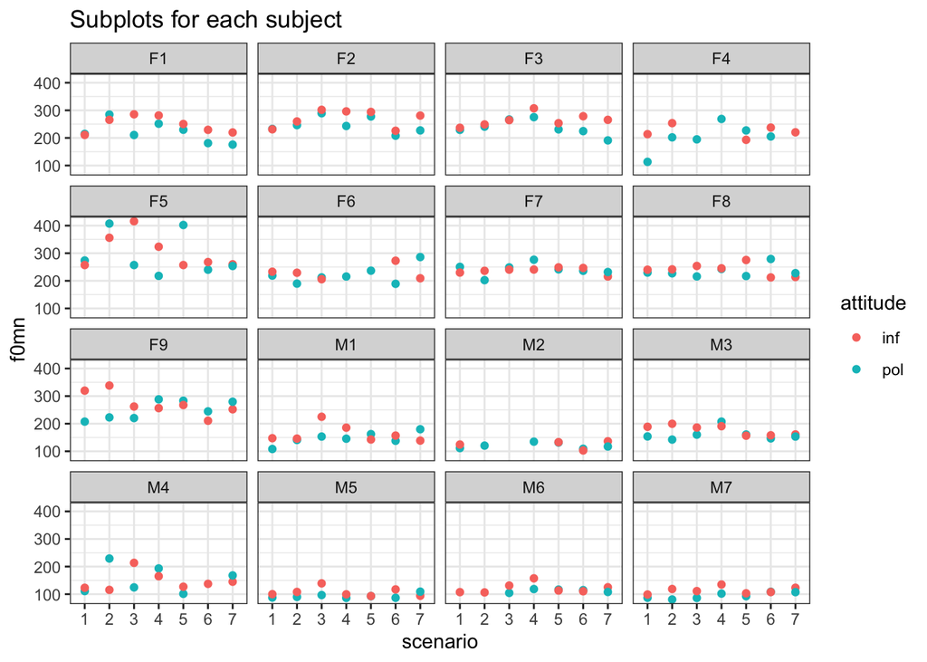

```r
politeness$scenario <- as.factor(politeness$scenario)

ggplot(politeness, aes(x = scenario, y = f0mn, color = attitude)) +
  geom_point() +
  facet_wrap(~subject) +
  labs(title = "Subplots for each subject") +
  theme_bw()
```

From visual inspection, one can observe a difference between female an male subjects, where females seem to have a higher mean frequency of voice pitch than males in general. Next, the plots give an indication of having a higher pitch in informal context than polite context.

## Exercise 2 - comparison of models

### 1) Build four models and do some comparisons

**i. a single level model that models *f0mn* as dependent on *gender***

```r
model_1 <- lm(f0mn ~ gender, data = politeness)
```

**ii. a two-level model that adds a second level on top of i. where unique intercepts are modelled for each *scenario***

```r
model_2 <- lme4::lmer(f0mn ~ gender + (1|scenario), data = politeness)
```

**iii. a two-level model that only has *subject* as an intercept**

```r
model_3 <- lme4::lmer(f0mn ~ gender + (1|subject), data = politeness)
```

**iv. a two-level model that models intercepts for both *scenario* and *subject***

```r
model_4 <- lme4::lmer(f0mn ~ gender + (1|subject) + (1|scenario), data = politeness)
```

**v. which of the models has the lowest residual standard deviation, also compare the Akaike Information Criterion `AIC`?**

```r
######### REWRITE THIS #######

deviance(model_2) # LOOK INTO THIS
```

```
## [1] 2144.314
```

```r
c(summary(model_1)$sigma,
  summary(model_2)$sigma,
  summary(model_3)$sigma,
  summary(model_4)$sigma
)
```

```
## [1] 39.46268 38.44800 32.04287 30.65803
```

```r
AIC(model_1, model_2, model_3, model_4)
```

|  | df | AIC |
| --- | --- | --- |
| model_1 | 3 | 2163.971 |
| model_2 | 4 | 2152.314 |
| model_3 | 4 | 2099.626 |
| model_4 | 5 | 2092.482 |

Model 4 (with two random intercepts) seems have to lowest residual standard deviation and also the lowest AIC. However, the AIC for model 4 is not much lower than the one for model 3.

**vi. which of the second-level effects explains the most variance?**

```r
# Looking at explained variance of each random intercept.
summary(model_4)$var
```

```
##  Groups   Name        Std.Dev.
##  subject  (Intercept) 24.2658
##  scenario (Intercept)  9.8067
##  Residual             30.6580
```

```r
# Extra: Explained residual variance for the whole model (random intercept for scenario)
sum(residuals(model_2)^2)
```

```
## [1] 304644.1
```

```r
# Extra: Explained residual variance for the whole model (random intercept for subject)
sum(residuals(model_3)^2)
```

```
## [1] 202911.3
```

Looking at the output from model 4, *subject* seems to explain the most variance (588.83) compared to *scenario* (96.17). Comparing the RSS from the model 2 and model 3 (each having one of the two variables as a random intercept), we also see a lower RSS for model 3, which means that much more variance is explained by model 3 ( *subject* as intercept) compared to model 2 ( *scenario* as intercept).

### 2) Why is our single-level model bad?

**i. create a new data frame that has three variables, *subject*, *gender* and *f0mn*, where *f0mn* is the average of all responses of each subject, i.e. averaging across *attitude* and_scenario_**

```r
politeness_2 <- politeness %>%
  select(subject = "subject", gender = "gender", f0mn = "f0mn") %>%
  filter(!is.na(f0mn)) %>%
  group_by(subject, gender) %>%
  summarise(f0mn_mean = mean(f0mn))
head(politeness_2)
```

| subject | gender | f0mn_mean |
| --- | --- | --- |
| F1 | F | 235.0786 |
| F2 | F | 258.1857 |
| F3 | F | 250.9929 |
| F4 | F | 211.7636 |
| F5 | F | 299.2286 |
| F6 | F | 224.8583 |

**ii. build a single-level model that models *f0mn* as dependent on *gender* using this new dataset**

```r
model_mean <- lm(f0mn_mean ~ gender, data = politeness_2)
```

**iii. make Quantile-Quantile plots, comparing theoretical quantiles to the sample quantiles) using `qqnorm` and `qqline` for the new single-level model and compare it to the old single-level model (from 1).**

**i). Which model’s residuals ($\epsilon$) fulfil the assumptions of the General Linear Model better?**

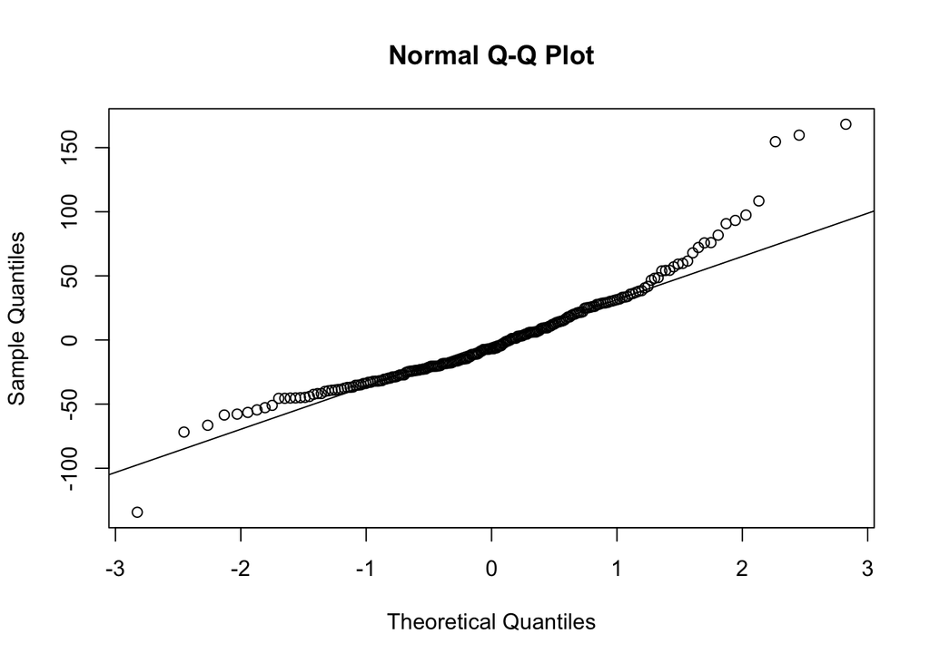

```r
qqnorm(residuals(model_1))
qqline(residuals(model_1))
```

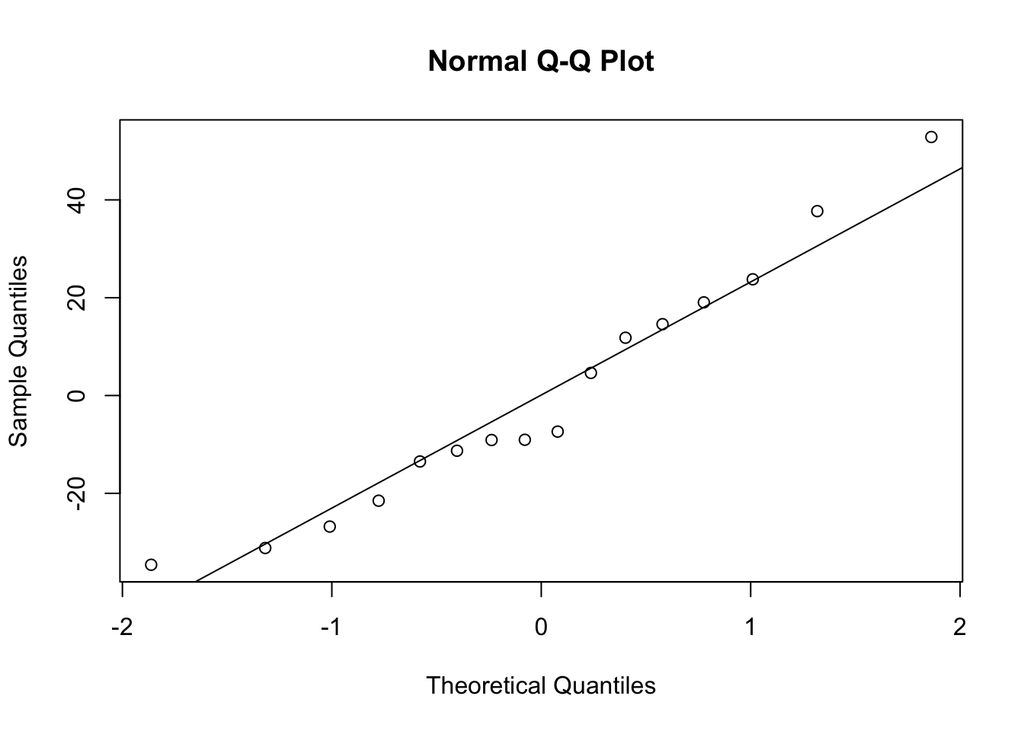

```r
qqnorm(residuals(model_mean))
qqline(residuals(model_mean))
```

Visual inspection indicates that the new single-level model does not have the same skew as the old single-level model seems to have. This might partly be explained by the fact that by taking the mean, the model will not have the same extreme values, as we no longer consider the individual data points.

**iv. Also make a quantile-quantile plot for the residuals of the multilevel model with two intercepts. Does it look alright?**

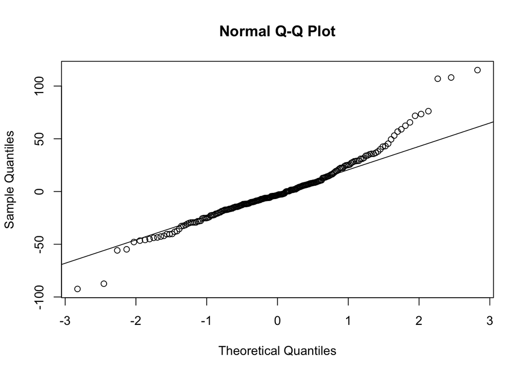

```r
qqnorm(residuals(model_4))
qqline(residuals(model_4))
```

Overall, most points seem to fall on a straight line, however, some points are deviating, especially to the right, which indicates a positive skew. Some of these could possibly be evaluated as outliers.

### 3) Plotting the two-intercepts model

**i. Create a plot for each subject, (similar to part 3 in Exercise 1), this time also indicating the fitted value for each of the subjects for each for the scenarios**

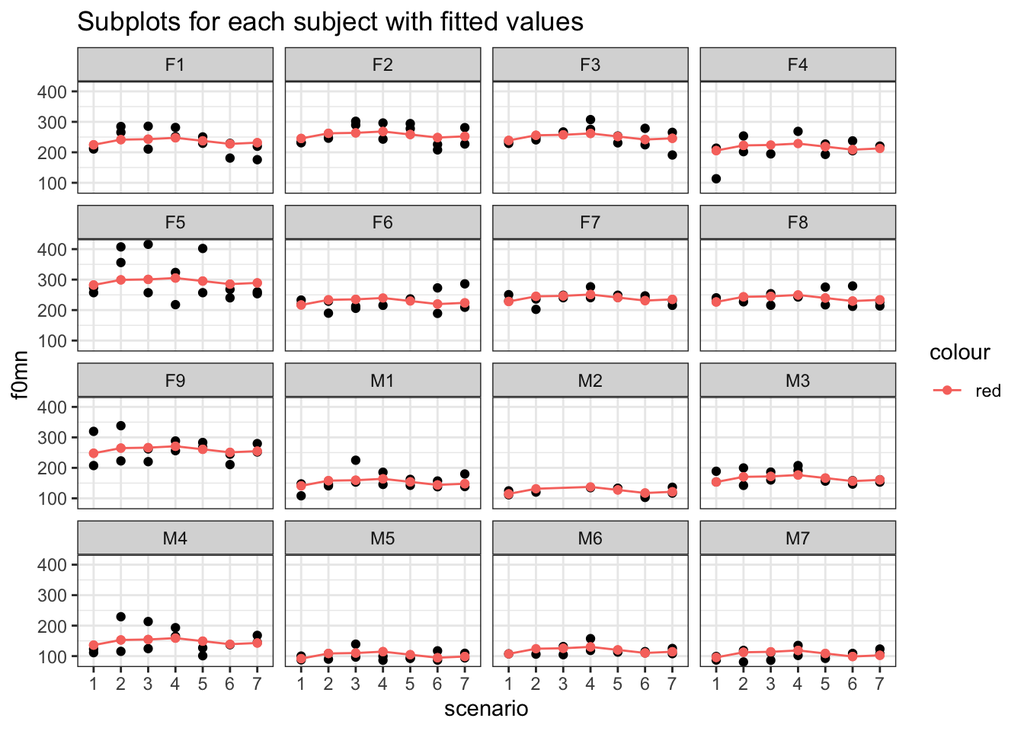

```r
# fitted() combines the fixed() with ranef() creating a fitted value for each subject in each scenario.

ggplot(politeness, aes(x = scenario, y = f0mn, group = subject)) +
  geom_point() +
  geom_point(aes(x = scenario, y = fitted(model_4), color = "red"))+
  geom_line(aes(x = scenario, y = fitted(model_4), color = "red")) +
  facet_wrap(~ subject) +
  labs(title = "Subplots for each subject with fitted values") +
  theme_bw()
```

## Exercise 3 - now with attitude

### 1) Carry on with the model with the two unique intercepts fitted ( *scenario* and *subject* ).

**i. now build a model that has *attitude* as a main effect besides *gender***

```r
model_5 <- lme4::lmer(f0mn ~ gender + attitude + (1|subject) + (1|scenario), data = politeness)
```

**ii. make a separate model that besides the main effects of *attitude* and *gender* also include their interaction**

```r
model_6 <- lme4::lmer(f0mn ~ gender*attitude + (1|subject) + (1|scenario), data = politeness)
```

**iii. describe what the interaction term in the model says about Korean men’s pitch when they are polite relative to Korean women’s pitch when they are polite (you don’t have to judge whether it is interesting)**

### 2) Compare the three models

#### *using residual variance, residual standard deviation and AIC.*

```r
# Residual variance for the whole model (RSS)

res_1 <- sum(residuals(model_4)^2)
res_2 <- sum(residuals(model_5)^2)
res_3 <- sum(residuals(model_6)^2)

# Residual Standard deviation
s_1 <- sigma(model_4)
s_2 <- sigma(model_5)
s_3 <- sigma(model_6)

AICs <- AIC(model_4, model_5, model_6)

tibble("Model"=c("Model 1","Model 2", "Model 3"), "Residual Variance"=c(res_1, res_2, res_3), "Sigma"=c(s_1, s_2, s_3), "AIC"=c(AICs[1,2], AICs[2,2], AICs[3,2]))
```

| Model | Residual Variance | Sigma | AIC |
| --- | --- | --- | --- |
| Model 1 | 181392.4 | 30.65803 | 2092.482 |
| Model 2 | 169253.2 | 29.71087 | 2077.131 |
| Model 3 | 168903.6 | 29.75684 | 2072.618 |

### 3) Choose the model that you think describe the data the best - and write a short report on the main findings based on this model.

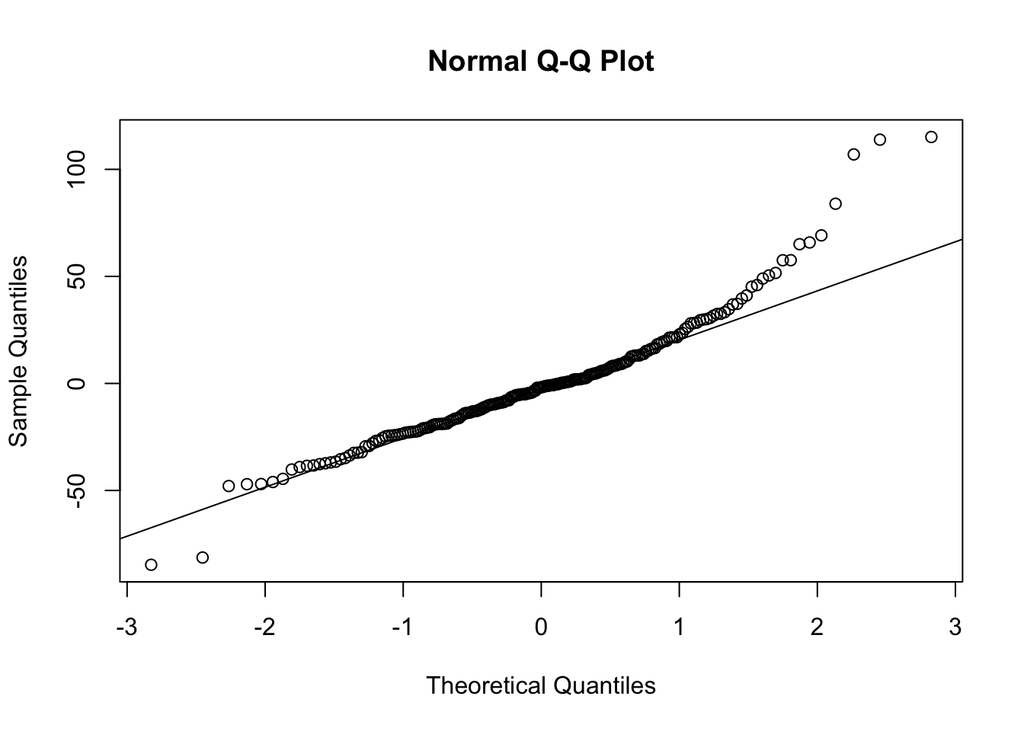

```r
qqnorm(residuals(model_5))
qqline(residuals(model_5))
```

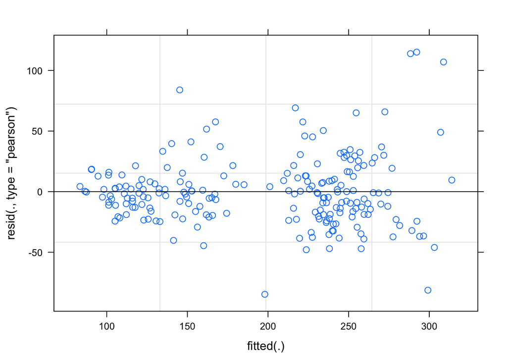

```r
plot(model_5)
```

The dataset consists of measurements of voice pitch of Korean males and females. Each subject are measured in seven different scenarios, and each scenario with a polite and informal attitude. This creates 14 different conditions for each subject. The mean frequency of voice pitch is measured for each condition. Conditions with missing data of mean frequency are removed from the dataset.

Three models are compared:

**Model 4 :** f0mn ~ gender + (1|subject) + (1|scenario)  
**Model 5 :** f0mn ~ gender + attitude + (1|subject) + (1|scenario)  
**Model 6 :** f0mn ~ gender*attitude + (1|subject) + (1|scenario)

A visual inspection of the Quantile-Quantile plot of the chosen model indicates that the data has a slightly positive skew (possibly a few outliers).

Including random intercepts in a model allows us to take individual starting points into consideration. When excluding a random intercept, e.g. for subjects, one might overlook an effect that is, in fact, existing. Where both subjects may experience an increase between trials but one of the subjects having values lower than the other subject, this will not be shown if their starting point is not taken into consideration. The same is the case for *scenario*. Also, by not including separate intercepts, one violates the assumption of independence because of the experiment being a repeated measures design.